# お世話になっている方への限定貸切レストラン

2025-02-05T12:23:10+06:00

限定貸切オープン！

#### **日時(1) 2025年3月8日(土) 17:00〜20:00(仕込み中 お酒のみ)**

#### **日時(2) 2025年3月9日(日) 13:00〜21:00(貸切)**

#### **場所 スカイツリーの近く、徒歩5分くらい**

[会場までのMAPはこちら](https://www.google.com/maps?q=35.708089714195054,139.80926961240868&zoom=16)

[figure not shown]

アクセス

### イベント告知

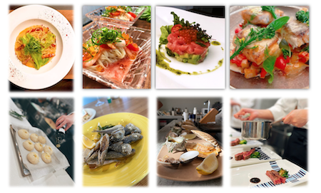

将来のレストランオープンに向けて(！？)

期間限定レストラン、開店します！洋食メインですが、お酒に合わせて調整します。アレルギーがございましたら、ご予約時にお知らせください。

ランチタイム(13:00〜15:00)はキッチンカウンターでミニコースを提供しています。４名〜５名のみのご予約制です。ラストオーダーなし。お好きな時間にご来店ください。

ディナータイム(16:00〜21:00)は、パーティスタイル！着席は10名が最大です！お好きな時間にご来店ください。

個人の食事やお酒の持ち込みOK。クラフトビールとウィスキー、ワインあたりは準備予定です。好きなお酒がある方は、事前オーダーかお持ち込みでお願いいたします！

ご予約はスタッフまで。

※ シェフ・パティシエ・ソムリエ・ホールスタッフ・賑やかし職人・看板お絵かき職人・お店やってみたい人、その他オープンポジション募集中です(スタッフ過多となる場合があります、お給料ありません、ご了承ください)。

※ 料理を準備して提供されたい方は、土曜日と日曜日の朝、店内で仕込み可能です。

### メニューと部構成

#### 3/8(土) 仕込みタイム 17:00〜20:00

- 仕込み時間: 特別枠でバー営業中(料理なし、味見のみ)。

#### 3/9(日) ランチタイム 13:00〜15:00 (ラストオーダーありません)

パスタランチ: 参加費2000円 (フリードリンク)

※ メニューは仕入れと体力次第で変更されます(下のメニューは前回のもの)。

[figure not shown]

ランチメニュー

(※ 店内で仕込み作業もしています)

#### 3/9(日) ディナータイム 16:00〜21:00 (22時完全閉店)

パーティーコース: 参加費4000円

※ メニューは仕入れと体力次第で変更されます(下のメニューは前回のもの)。

[figure not shown]

ディナーメニュー

### 会場 (東京 浅草~押上 スカイツリーからすぐ)

#### キッチンスタジオ - ATELIER295

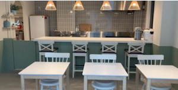

場所

### アクセス

[会場までのMAP](https://www.google.com/maps?q=35.708089714195054,139.80926961240868&zoom=16)

#### 〒1300002 東京都 墨田区 業平 1-7-9 PLAT295 1F

[figure not shown]

アクセス

東京スカイツリー駅から徒歩5分くらい

押上駅から徒歩7分くらい

浅草駅から徒歩10分くらいです。

※ 道に迷われましたら、スタッフまでご連絡ください。

### 特別協力(Special Thanks)

### Beer Park “LANA Beer”

JR南武線 武蔵溝ノ口から徒歩5分

ビールの注ぎ手が注ぐ、街のビール屋(HPより)

特別なクラフトビールを限定入荷予定です。

ぜひチェック！

[Beer Park LANA Beerさまのホームページはこちら](https://www.lana-beer.com/)